# R class 1-1-4 class book

Yichun Sung

2018/9/13

## 資料型態

- 在整理資料的時候，新手常常會犯錯或是找不到錯誤的地方常常在資料型態上的轉換出現錯誤。
- 其實不只是新手，老手也常會忘記確認資料格式。
- 第一步，使用`class()`函式去確認資料的型態/格式。

```r
numericVector <- c(1:50)
numericVariable <- 1823.723
integerVariable <- 44

class(numericVector)
class(numericVariable)
class(integerVariable)

characterVector <- c("Jay", "Kyle", "Andy", "Frank", "Eve", "Zack", "Lulu")
class(characterVector)

mixVector <- c("Jay", "Kyle", "Andy", "Frank", "Eve", "Zack", "Lulu", 5, 1, 12313, 123.123)
class(mixVector)
```

- 認識在R語言中幾種很重要而且很常用的資料型態/格式
  - 元素層級：
    1. 數值 numeric
    2. 數值中的整數 integer，integer = numeric，但是並不是所有numeric都等於integer
    3. 邏輯值 logical
    4. 日期值 Date
    5. 時間值(除了日期外再加入時分秒) “POSIXct” “POSIXt”
    6. 空值 NULL
    7. 遺失值 na
  - 向量層級：
    1. Vector
    2. Factor
  - 二維以上的層級：
    1. matrix
    2. data.frame
    3. list
    4. array
- 使用`class()`去觀察資料型態

```r
aNumericVector <- c(1.1:14) # numeric
aIntegerVector <- c(1:5) # integer
aDateElement <- as.Date("2018-09-01") # 日期 2018年9月1日
aPOSITXct <- as.POSIXct("2018-09-01 11:23:43") # 時間：2018年9月1日 早上11點23分43秒

class(aNumericVector)
```

```
## [1] "numeric"
```

```r
class(aIntegerVector)
```

```
## [1] "integer"
```

```r
class(aDateElement)
```

```
## [1] "Date"
```

```r
class(aPOSITXct)
```

```
## [1] "POSIXct" "POSIXt"
```

以此類推，你可以自己試試看去觀察各種資料型態。

## Data frame 運算

我們先建立一個Data frame來練習：

這是MLB球隊 西雅圖水手隊其中四位球員2018年截至2018-09-18的成績。

```r
playerName <-c("Haniger, M", "Seager, K", "Cruz, N", "Segura, J") # 球員名字
position <- c("RF", "3B", "DH", "SS") # 守備位置
game <- c(147, 144, 132, 133) # 出賽數
AB <- c(557, 548, 476, 545) # 打數
H <- c(157, 121, 126, 167) # 安打數
HR <- c(25, 21, 36, 9) # 全壘打支數
BB <- c(66, 36, 50, 28) # 四壞球數

SeattleMariners <- data.frame(playerName, position, game, AB, H, HR, BB, stringsAsFactors = FALSE)
```

### 新增欄位

上述的data frame完成，但由於我們常常會因為計算出新的資料，因此我們需要新增一個欄位儲存這筆新的資料。

```r
# 假如我們要新增一個欄位，去計算球員的打擊率 H/AB

BA <- SeattleMariners$H/SeattleMariners$AB # 打擊率

# 算完之後新增欄位

SeattleMariners$BA <- BA # 新增一個col名稱為"BA"的欄位

# 用 cbind函式

SeattleMariners <- cbind(SeattleMariners, BA)
```

### 新增列

新增一個球員的資料

```r
newPlayer <- c("Cano, R", "2B",69,264,73,8,30)

SeattleMariners <- rbind(SeattleMariners, newPlayer)
```

### 重新命名欄位

```r
newDataFrame <- data.frame(title1 = c(1:5),
                          title2 = c("one", "two", "three", "four", "five"),
                          title3 = c("Sam", "Kyle", "Seager", "Alex", "Joyce"))

names(newDataFrame) # 印出newDataFrame的所有欄位名
```

```
## [1] "title1" "title2" "title3"
```

```r
names(newDataFrame)[1] # 印出newDataFrame的第一欄欄位名
```

```
## [1] "title1"
```

```r
names(newDataFrame)[1] <- "new_Title1" # 將newDataFrame的第一欄位名改成"new_Title1"
names(newDataFrame) <- c("new_title1", "new_title2", "new_Title3") # 將newDataFram 一到三欄欄位名更改
```

### 觀察data frame和簡單的計算

```r
newDataFrame <- data.frame(title1 = c(1:5),
                          title2 = c("one", "two", "three", "four", "five"),
                          title3 = c("Sam", "Kyle", "Seager", "Alex", "Joyce"))


dim(newDataFrame) # data frame維度
```

```
## [1] 5 3
```

```r
str(newDataFrame) # 觀察結構
```

```
## 'data.frame':    5 obs. of  3 variables:
##  $ title1: int  1 2 3 4 5
##  $ title2: Factor w/ 5 levels "five","four",..: 3 5 4 2 1
##  $ title3: Factor w/ 5 levels "Alex","Joyce",..: 4 3 5 1 2
```

```r
summary(newDataFrame)
```

```
##      title1    title2     title3
##  Min.   :1   five :1   Alex  :1
##  1st Qu.:2   four :1   Joyce :1
##  Median :3   one  :1   Kyle  :1
##  Mean   :3   three:1   Sam   :1
##  3rd Qu.:4   two  :1   Seager:1
##  Max.   :5
```

```r
max(newDataFrame$title1) # 找最大值
```

```
## [1] 5
```

```r
min(newDataFrame$title1) # 找最小值
```

```
## [1] 1
```

```r
mean(newDataFrame$title1) # 找平均值
```

```
## [1] 3
```

## 讀取csv檔

可以用內建的`read.csv()`，也可使用套件`data.table::fread()`

```r
# newCSVtable <- read.csv()
# 套件data.table
# newCSVtable <- fread()
```

讀取book_data的資料

```r
setwd("~/documents/github_rep/R_class_notebook/初學班/第一週")# 選取資料路徑
#setwd("~/documents/R_class_notebook")
# member data
members <- read.csv("class_data/book_data/member.csv")
book <- read.csv('class_data/book_data/book.csv')
event <- read.csv('class_data/book_data/event.csv')
names(event)[2] <- "cid"
```

## 篩選和 Join

### Inner join

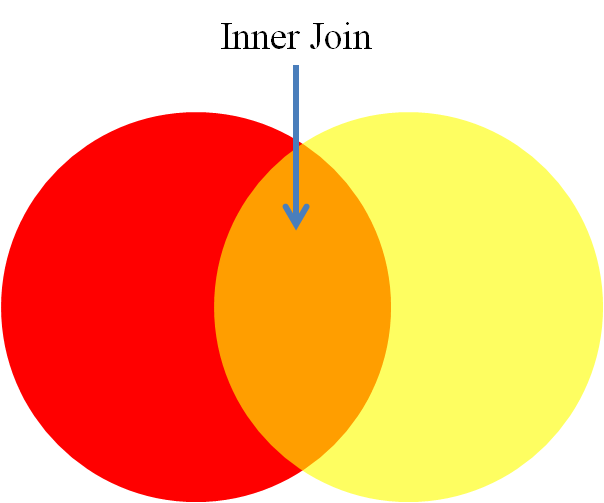

```r
Inner_join_event_df <- merge(x = event, y = members, by.x = "cid", by.y = "id")
```

### Left join

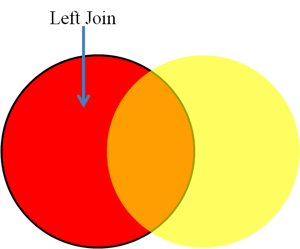

```r
Left_join_event_df <-  merge(x = event,
                             y = members,
                             by.x = "cid",
                             by.y = "id",
                             sort = TRUE,
                             all.x = TRUE,
                             all.y = FALSE)
```

### Right join

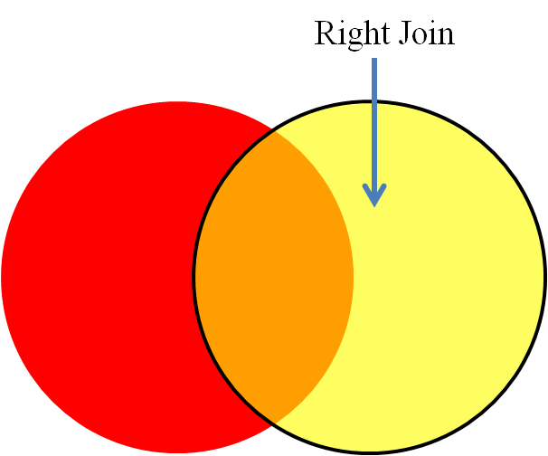

```r
Right_join_event_df <-  merge(x = event,
                             y = members,
                             by.x = "cid",
                             by.y = "id",
                             sort = TRUE,
                             all.x = FALSE,
                             all.y = TRUE)
```

### Full join

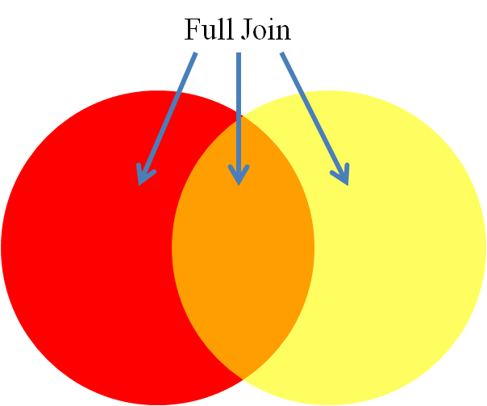

```r
Full_join_event_df <-  merge(x = event,
                             y = members,
                             by.x = "cid",
                             by.y = "id",
                             sort = TRUE,
                             all.x = TRUE,
                             all.y = TRUE)
```

## 篩選

### 選擇前N個欄位

```r
newDataFrame <- data.frame(title1 = c(1:5),
                          title2 = c("one", "two", "three", "four", "five"),
                          title3 = c("Sam", "Kyle", "Seager", "Alex", "Joyce"))

newDataFrame2 <- newDataFrame[, c(2:3)] # 選擇第二和第三個欄位
newDataFrame3 <- newDataFrame[, c("title1", "title3")] # 選擇名為 "title1"和"title3"欄位的資料
```

### 刪除變數、欄位

```r
newDataFrame4 <- newDataFrame[, -1] # 刪除第一個欄位
newDataFrame5 <- newDataFrame[-2, -1] # 刪除第二個列位和第一個欄位
```

### Subset

但如果想要針對比較精確的篩選，例如資料中性別為女性、身高超過175公分的客人或是年紀45歲以上的客人，

針對這樣的需求，我們可以用`subset()`這個函式來做到。

以下我們用剛剛從外部讀取的members資料來演示。

```r
# 如果我們只要篩選出女性的資料
f_members <- subset(members, members$gender == "f")

# 篩選身高超過175cm的客戶資料
members_175 <- subset(members, members$height > 175)

# 篩選年齡低於45(包含45)的客戶資料
members_under45 <- subset(members, members$age <= 45)

# 篩選身高165到175之間的男性客戶資料
new_member <- subset(members, members$gender == "m" & members$height > 165 & members$height <= 175)
```

## 儲存資料

將初步的資料整理完後，可以將資料儲存成csv檔供後續其他工作夥伴使用。

請善用`write.csv()`函式

```r
# 把剛剛篩選好的資料存檔。
write.csv(new_member, "~/Documents/new.csv")
```